# DATA100 Introduction to Data Analytics

Lecture 16: Relationships Between Variables

Agassi Iu

Wilfrid Laurier University

2026-11-19

## Where we left off

**Recall from pre-Midterm 1**

**Covariation** is the tendency for two variables to move together. If they covary, knowing one improves your guess about the other.

Today we turn that idea into something we can write down, fit, and check: a model.

- Lecture 16 (today): one outcome, one predictor
- Lecture 17 (next Tuesday): adding structure (categories and interactions)

## Model

**What is a model?**

A simplified, written-down description of how one variable changes with another. It is never the whole truth, but it can be useful.

Models do different jobs:

- *Descriptive:* summarize a pattern in the data
- *Inferential:* test a claim about the world
- *Predictive:* estimate values we have not observed

Today’s example is mostly about inferential. Try and ask yourselves these questions: is there a relationship among these variables, and how big is it (can you quantify it)?

# The sleep survey

## The sleep survey

| Variable | Meaning |
| --- | --- |
| `program` | the student’s program: Arts, Business, Engineering, Health Sci, Science |
| `num_courses` | number of courses this term |
| `study_hours_week` | hours spent studying per week |
| `sleep_hours` | **hours of sleep per night** |
| `favourite_drink` | Coffee, Tea, Energy drink, Pop, Water |
| `has_early_class` | does the student have an early class? Yes or No |
| `work_hours_week` | hours of paid work per week |
| `stress_level` | self-reported stress, 1 to 5 |
| `sleep_quality` | self-reported sleep quality, 1 to 5 |
| `avg_grade` | **average grade (%)** |

## Simple Scatterplot

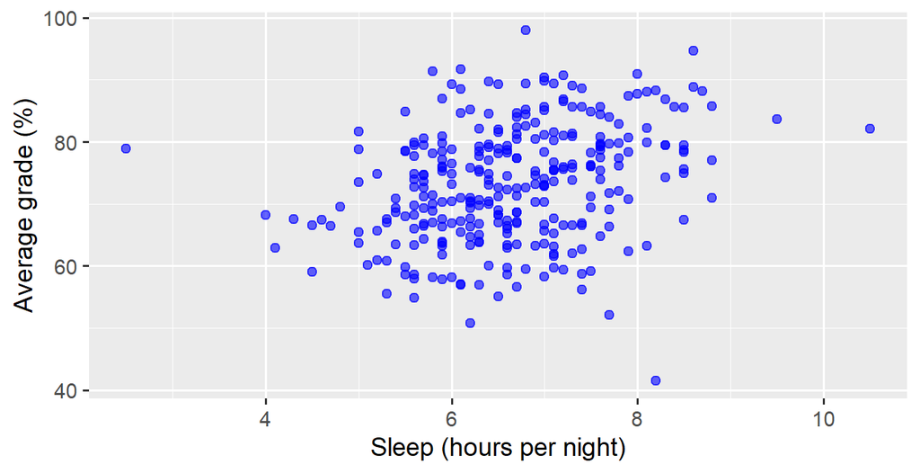

```r
ggplot(survey, aes(x = sleep_hours, y = avg_grade)) +
  geom_point(size = 2, alpha = 0.6,col="blue") +
  labs(x = "Sleep (hours per night)", y = "Average grade (%)")
```

## Checkpoint

**Questions to ask of any scatterplot**

1. Is the relationship going up or down?
   - Up suggests a positive association; down suggests a negative one.
2. If you were to draw a line of best fit, is it roughly a straight line or a curve?
   - If the variables are related, the pattern may be more than linear. A straight line will miss any bend in the points.
3. How strong is it: do the points hug a line, or scatter widely?
   - If the points hug the pattern, knowing `x` gives a sharp guess for `y`. If they scatter widely, the trend may still be real, but any single prediction is rough.
4. Are there any unusual points?
   - Remember the outliers? Check whether they are errors or real observations before deciding what to do with them.

## A question we can test

Before looking at a model, we should write down what we want to find out.

**Null hypothesis**

Sleep has **no relationship** with average grade.

- In statistical inference, we compare the null hypothesis against the *alternative hypothesis*, which in this case, represents “sleep has *some* relationship with average grade.

If the null hypothesis was true, the best line through the points would be flat. So: how flat is it?

**Group project relevance**

*Hopefully you have already done this part for your project by now.*

## Adding a straight line

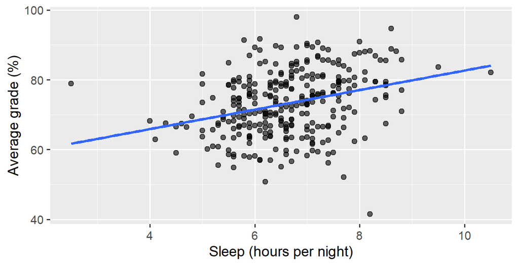

```r
ggplot(survey, aes(x = sleep_hours, y = avg_grade)) +
  geom_point(size = 2, alpha = 0.6) +
  geom_smooth(method = lm, se = FALSE) +
  labs(x = "Sleep (hours per night)", y = "Average grade (%)")
```

`method = lm` asks for a **linear model**. Now let’s fit one ourselves.

# Fitting a line

## The model formula

```r
y ~ x
```

- The outcome goes on the left of the tilde `~`.
- The predictor goes on the right
- Read it as: “`y` explained by `x`”
  - Sometimes we also call `x` the explanatory variable and `y` as the response variable.

**The formula is symbolic**

`avg_grade ~ sleep_hours` does not compute anything. It describes the *role* of each column in the model.

## Fitting a Linear Model

**`lm()`**

The function `lm(formula,data)` is used for linear modelling. There are primarily two important arguments: a formula and a data frame. The simplest examples of a linear model can be

- `lm(y~x)`: linear model of `x` on the variable `y` (not from any data sets)
- `lm(y~x,df)`: linear model of `x` on the variable `y` from the data frame `df`
- `lm(y~x1+x2,df)`: linear model of both `x1` and `x2` on the variable `y` from the data frame `df`.

## Example of Linear Model

```r
sleep.lm <- lm(avg_grade ~ sleep_hours, data = survey)
sleep.lm
```

```
Call:
lm(formula = avg_grade ~ sleep_hours, data = survey)

Coefficients:
(Intercept)  sleep_hours
     54.718        2.795
```

## Reading the coefficients

A straight-line model has two coefficients:

$$\hat{y} = b_0 + b_1 x$$

**Slope (b1)**

The change in the predicted `y` when `x` increases by **1 unit**.

- If `x` goes **up** by 1, predicted `y` changes by **+ $b_01$**
- If `x` goes **down** by 1, predicted `y` changes by **− $b_1$**
- **Positive** slope: predicted `y` goes **up** by $b_1$ when `x` increases by 1
- **Negative** slope: predicted `y` goes **down** by $b_1$ when `x` increases by 1
- **Zero** slope: predicted `y` does **not change** on whatever value of `x`.

**Intercept (b0)**

The predicted `y` when `x = 0`. It is where the line crosses the y-axis. That is what `y` is expected to be when `x` is nothing.

## Remarks

**What we observed**

The intercept is 54.7180 and the slope for `sleep_hours` is 2.7945.

**Conclusion**

- “The average grade for students who have slept for zero hours is 54%”.
- “For every extra hour of sleep per night, a student’s predicted average grade changes by 2.7945 percentage points.”
- Is the effect large or small compared with how much grades vary between students?
- Would you bet on this prediction for any one student? Think back to the scatter plot.

## Exercise

**Find the effect of study time on grades**

1. Fit `avg_grade ~ study_hours_week`.
2. Does the slope and intercept make sense in real life?
3. Plot a scatterplot with a linear regression line to check it yourself.

# Reading the output

## Summary of `lm()`

**Ugh. R is so lazy!!! ٩(ˋᗣˊ*)و**

The `lm()` output only gives you minimal information. The coefficient table is not built until you ask for it with `summary()`.

```r
summary(sleep.lm)
```

```
Call:
lm(formula = avg_grade ~ sleep_hours, data = survey)

Residuals:
    Min      1Q  Median      3Q     Max
-36.133  -6.140   0.276   6.233  24.279

Coefficients:
            Estimate Std. Error t value Pr(>|t|)
(Intercept)  54.7180     3.4165  16.016  < 2e-16 ***
sleep_hours   2.7945     0.5083   5.498 8.28e-08 ***
---
Signif. codes:  0 '***' 0.001 '**' 0.01 '*' 0.05 '.' 0.1 ' ' 1

Residual standard error: 8.881 on 298 degrees of freedom
Multiple R-squared:  0.09208,   Adjusted R-squared:  0.08903
F-statistic: 30.22 on 1 and 298 DF,  p-value: 8.283e-08
```

## The coefficient table

| Column | What it tells you |
| --- | --- |
| `Estimate` | the fitted value of the intercept or slope |
| `Std. Error` | how much that estimate would wobble across similar datasets |
| `t value` | the estimate divided by its standard error |
| `Pr(>\|t\|)` | the p-value for the null hypothesis that the true coefficient is 0 |

- A small p-value on the `sleep_hours` row is **evidence against** the null hypothesis that sleep has no relationship with grades.
- Normally when we read a summary table of regression model, a low p-value using has “*”, ”**”, ,or ”***” next to it as an indication.

# Predicting

## Modelling Predictions

**Prediction**

The function `predict(model, values)` takes new `values` and plugs them into the fitted `model`. It returns the predicted outcome `y` for each one.

The `values` are new values of your predictor `x`. They can be any values you choose, not only ones that appear in your data, as long as they are in a data frame with a column named the same as the predictor in the model (here, `sleep_hours`).

```r
new_values <- data.frame(sleep_hours = c(0, 4, 7, 9, 12))
predict(sleep.lm, new_values)
```

```
       1        2        3        4        5
54.71799 65.89612 74.27973 79.86879 88.25240
```

## The applicable range

```r
range(survey$sleep_hours)
```

```
[1]  2.5 10.5
```

**Training data vs. new data**

The data we used to build the model is its **training data**. The model only learns patterns from what it has seen. Anything we predict for afterwards is **new data**.

**Extrapolation**

Predictions are only as trustworthy as new data is similar to the training data. When `x` falls **outside the range we observed**, that is extrapolation: the straight-line pattern may not continue.

## Line Extending Outside of Data?

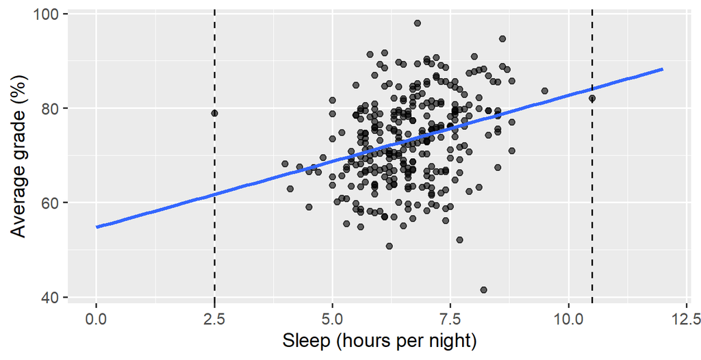

## Exercise

**Does studying more imply better grades?**

1. Use `range()` to find the lowest and highest `study_hours_week` in `survey`.
2. Predict the average grade at 0, 10, 20, and 30 hours.
3. Should you trust these numbers?
4. Predict how many hours do you have to study in a week in order to get 80%+ average.

## Residuals: the leftovers

A **residual** is the gap between an observed value and the model’s fitted value. Points above zero have a higher grade than the line predicts, points below have a lower one.

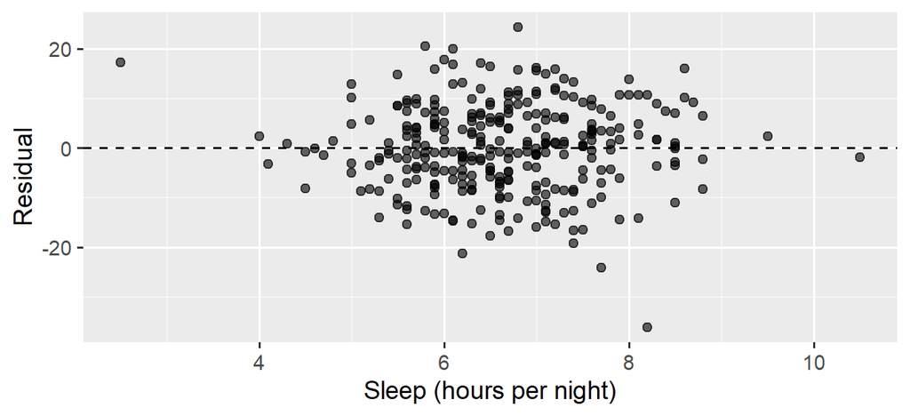

## Summary

- A model is a simplified description of how an outcome changes with a predictor
- The formula `y ~ x` names the outcome on the left and the predictor on the right
- `lm()` fits the line. But we need `summary()` to gives estimates, standard errors and p-values
- How to interpret the slope?: The change in predicted `y` for a 1-unit increase in `x`

**Next Class**

We are going to look at multiple effects. Do all programs look the same? Is one line enough? Can we find out if variables that related to each other can be used for the same model? What are the other values printed underneath in the `summary(lm(...))`?